# Register specificity in the English genitive alternation

DGfS 2017, Saarbrücken

## Introduction

## Variationist approach to grammar

- Linguistic variables are conditioned by multiple constraints
- Grammatical knowledge includes implicit knowledge of the quantitative associations (probabilities) between variables and their constraints ( 'variable rules')
- This knowledge is (in large part) derived from experience, and an individual’s grammar is subtly (re)constructed throughout their lifetime
- Individuals within a community converge on shared norms for constraint effects ( 'orderly heterogeneity')

## Different constraints → different grammars

**Shared Constraints Hypothesis:**  
Individuals within a community share a set of constraints on variable processes (Guy 2004, 2015)

**Grammatical Differences Hypothesis:**  
Having different constraint effects means having a different grammar, and generally that means belonging to a different speech community

- Internal contraints are generally thought to be independent of stylistic factors (e.g. Labov 2010)
- What varies across users in stylistic practice is the overall rate of use of a variant

## What is the scope of stylistic variation?

**Register:** *"A variety of a language that is associated with particular functional or situational features[…]"*

- more expansive definition than just formality or attention to speech (see also Rickford 2014)
- encompasses variability across **all speaking and writing practices** that make up the entire repertoire of a community
- variability across registers—esp. *written* registers—is (relatively) uncharted territory in variationist research (but see, e.g., Hinrichs & Szmrecsanyi 2007; Jankowski 2013; Grafmiller 2014; Pijpops & Van de Velde 2014)

## Today's talk

Investigate the sensitivity of a linguistic variable (English genitives) to register effects

**Research questions**

1. To what extent are internal contraints sensitive to stylistic variation?
   - do we find register-specific changes in factor effects?
2. Do individual speakers/writers vary in their use of certain constraints?
   - how consistent are users w.r.t. certain factors?
   - can we find evidence that speakers vary constraint effects
3. How much can such investigations tell us about the possible existence of register-specific grammars

## Case study

## English genitive alternation

1. the best interest of both governments [*of*-genitive]
2. both governments' best interest [*s*-genitive]

Well-researched phenomenon (Rosenbach 2014)

- relatively stable across regional varieties (Heller et al. 2017)
- historically quite variable (Wolk et al. 2013)
- evidence for recent parallel increases in use of *s*-genitives across vernacular AmE and newspaper writing (Biber 2003; Hundt & Mair 1999; Hinrichs & Szmrecsanyi 2007)
- variation in other written registers not so well-studied (cf. Grafmiller 2014)

## Data: Brown family of corpora

Parallel corpora of 20<sup>th</sup>C. written US and UK English, sampled across 30-year time spans (Francis & Kucera 1979; Mair & Ludwigs 1999)

- 1900 > 1930 (B-Brown) > **1960 (Brown)** > **1990 (Frown)**
- include data from 15 registers/genres
- approx. 1 million words per corpus

## Present dataset (*N* = 5096)

Focus on 5 registers of US English from the 1960s (Brown) & 1990s (Frown)

- **Press**: newspaper reportage
- **Learned**: academic books & papers
- **Non-fiction**: memoirs, biographies, letters
- **General fiction**
- **Adventure fiction**: e.g. westerns

Extract all instances of interchangeable genitives (Rosenbach 2002; Hinrichs & Szmrecsanyi 2007; Grafmiller 2014)

## Distribution of genitives by time and genre

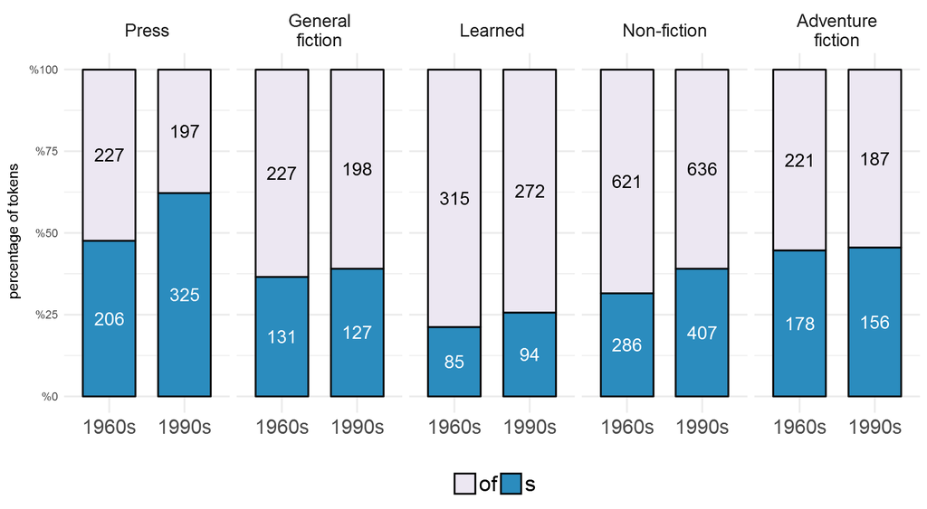

## By-author (*N* = 177) variability in Brown/Frown

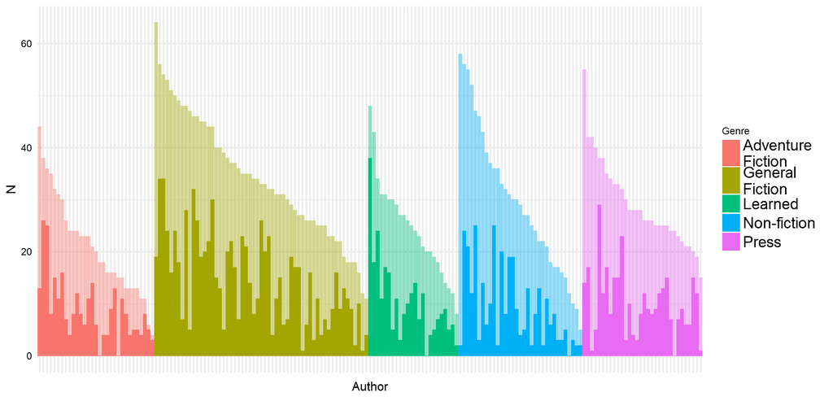

Light bars = total number of tokens, Dark bars = number of s-genitives

[figure not shown]

## Factors coded for

- **Possessor animacy** (animate vs. inanimate)
- **Possessor/possessum length** in words
- **Possessor NP type** (proper vs. common)
- **Final sibilant** (Y/N)
- **Possessor givenness** (given vs. new)
- **Possessor thematicity** (log text frequency)
- **Semnatics** (prototypical vs. non-prototypical)
- **Type-token ratio**
- **Prior genitive** (*s* vs. other)

## Analysis

## Comparative sociolinguistic method

3 lines of evidence (Poplack & Tagliamonte 2001; Taglimonte 2002)

Looking across the registers…

1. Which factors (constraints) are significant?
2. How are factors ranked in terms of effect strength?
3. What is the ordering of the levels within the factors (the effect direction)?

Differences in these lines of evidence would imply different grammars

## Analysis: Identifying significant effects

Which factors are significant?

- assess significance via mixed-effects logistic regression
  - by-author random intercepts (individual base rates)
  - by-author random slopes for possr animacy (individual constraint effects)
- fit separate models to each register individually (predicting *s*-genitive)
  - identify which factors determine variant choice
  - examine direction (hierarchy) of contraint effects

**Do the same factors significantly affect genitive choice in the different registers, in the same direction?**

## Significant effects (log odds scale)

|  | Press | General fiction | Learned | Non-fiction | Adventure fiction |
| --- | --- | --- | --- | --- | --- |
| (Intercept) | -0.69 | -3.04 | -2.71 | -2.78 | -2.80 |
| Possr = Animate | 1.55 | 2.98 | 3.08 | 2.91 | 4.19 |
| Possr length (words) | -3.95 | -3.68 | -2.25 | -3.82 | -3.64 |
| Possm length (words) |  | -1.67 |  | 0.44 | -2.08 |
| Final.Sibilant = present | -0.70 |  | -2.21 | -1.61 |  |
| Possr = new | -0.61 |  | -1.87 | -0.56 | -1.42 |
| TypeTokenRatio |  | 0.75 |  | 0.46 |  |

## Significant effects (cont.)

|  | Press | General fiction | Learned | Non-fiction | Adventure fiction |
| --- | --- | --- | --- | --- | --- |
| PossrLog.Freq | 1.07 | 0.82 |  | 0.80 | 0.97 |
| Possr.Type = ProperN | 1.28 |  | 1.08 | 0.98 | 1.19 |
| Prior.gen = s |  |  |  | 0.45 |  |
| Semantics = prototypical |  | 0.84 |  |  |  |
| Time:Possr = Animate |  |  |  | -0.83 | -1.48 |
| Time:Possm length (words) | -1.53 | -1.85 | -2.78 | -3.29 | -4.49 |
| Time:Possr = new |  |  | 2.76 | 0.91 |  |

## Analysis: Assessing relative strength

What is the relative contribution of factors across registers?

- fit one model to combined dataset with same random factors
  - include interaction terms of internal constraints with **Genre** and **Time** (treatment coding with 'Press' as the reference level)
  - significant interaction terms are strong evidence variation in factor strength
- compute variable importance rankings for individual register models
  - different rankings reflect different degrees of explanatory power-

**Do certain factors vary in the strength of their effects by register?**

## Variability in animacy constraint

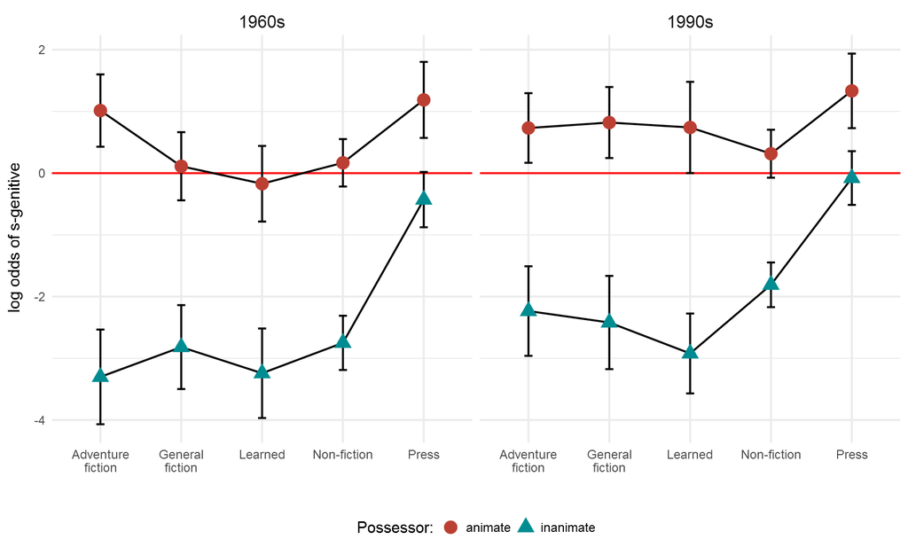

## Variable importance

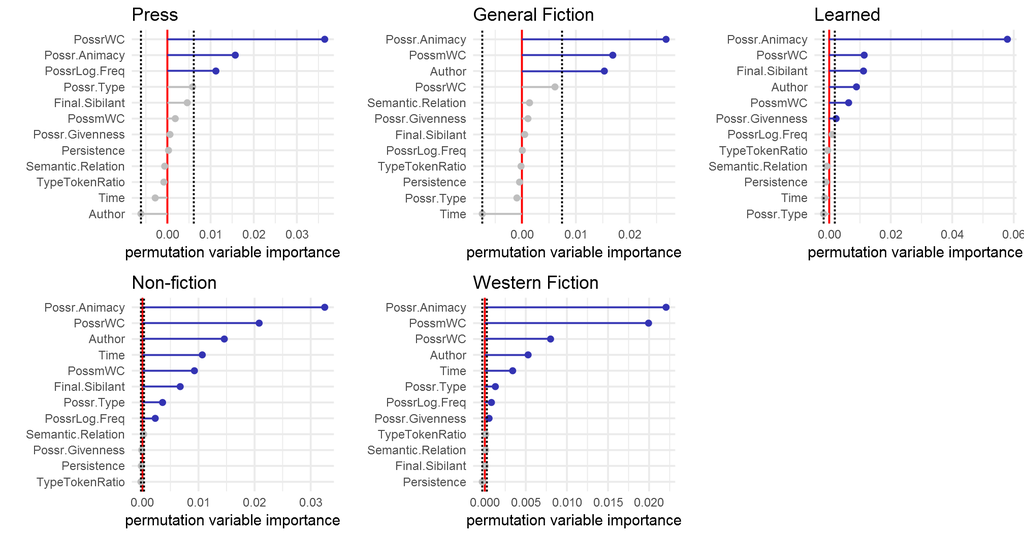

## Individual writers vs. the community

Compare influence of certain constraints (**possr animacy**) for individual writers to that of the register as a whole

- use by-author slopes for animacy derived from the mixed-effects model (e.g. Forrest 2015)
- do individuals' constraint effects match up to the aggregate patterns?
- some variability is expected, but the direct of the effect should stay the same

## Animacy effects among 1960s writers

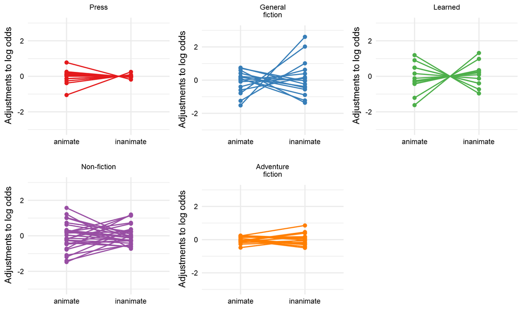

## Animacy effects among 1990s writers

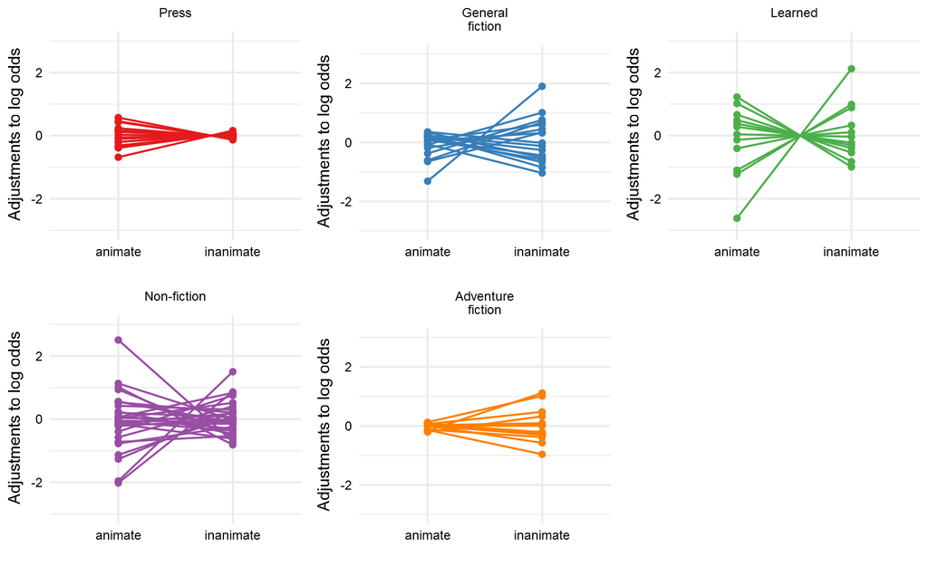

## Individual differences

"…most sociolinguistic, and social-semiotic variation [involves] rates of use. When the contexts of use differ, different grammars are involved." (Guy 2015)

- we observe both different rates AND (some) different contexts across individuals
- but individual variation in animacy effects only apparent in some registers
- again, high degree of consistency among authors suggests the emergence of a unique Press grammar

## Remaining questions

- How can we define a threshold beyond which an individual's (or register's) constraint effects can be considered a reflection of a distinct grammar?
  - no two speakers ever have exactly the same experience, hence differences across individuals will always exist
  - at what point do differences become large enough to "notice" and become available for indexical purposes?
  - statistical significance is not a good metric
- How can we investigate register sensitivity within individuals directly
  - same individual, different registers
  - corpus data are ill-suited for this

## Remaining questions

To what extent are our models of different grammars dependent on the tools we use to identify them?

- different analytical techniques can yield very different results… so which should we use?
- how do we incorporate results of multiple, possibly conflicting, techniques into comparative sociolinguistics?

## Variable importance (regression)

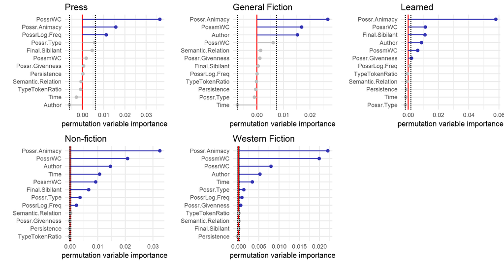

## Variable importance (random forest)

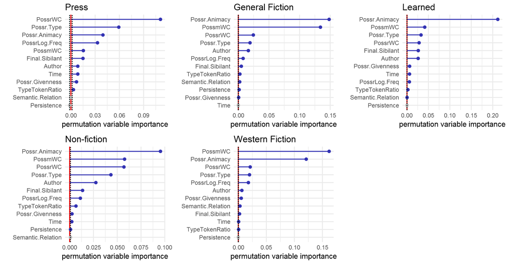

## Variable importance (naive discr. learner)

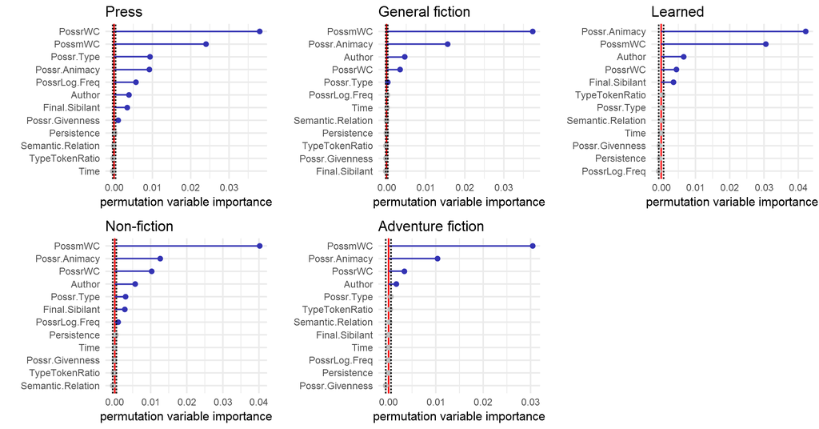

**Thank you!**

Contact: jason.grafmiller@kuleuven.be

## References

Biber, Douglas. 2003. Compressed noun-phrase structures in newspaper discourse. In Jean Aitchison & Diana M. Lewis (eds.), *New Media Language*, 169–181. London: Routledge.

Francis, W. N. & H. Kucera. 1979. *A Standard Corpus of Present-Day Edited American English, for use with Digital Computers (Brown)*. Providence, RI: Brown University.

Grafmiller, Jason. 2014. Variation in English genitives across modality and genres. *English Language and Linguistics* 18(3). 471–496. doi:10.1017/S1360674314000136.

Guy, Gregory R. 2015. Coherence, constraints and quantities. *Paper presented at NWAV 44*. Toronto. October 23.

Heller, Benedikt, Benedikt Szmrecsanyi & Jason Grafmiller. 2017. Stability and Fluidity in Syntactic Variation World-Wide: The Genitive Alternation Across Varieties of English. *Journal of English Linguistics* 45(1). 3–27. doi:10.1177/0075424216685405.

Hinrichs, Lars & Benedikt Szmrecsanyi. 2007. Recent changes in the function and frequency of Standard English genitive constructions: A multivariate analysis of tagged corpora. *English Language and Linguistics* 11(3). 437–474. doi::10.1017/S1360674307002341.

Hundt, Marianne & Christian Mair. 1999. 'Agile’ and 'uptight’ genres: The corpus-based approach to language change in progress. *International Journal of Corpus Linguistics* 4. 221–242.

## References (cont.)

Jankowski, Bridget L. & Sali A. Tagliamonte. 2014. On the genitive’s trail: data and method from a sociolinguistic perspective. *English Language and Linguistics* 18(2). 305–329. doi:10.1017/S1360674314000045.

Labov, William. 1966. The linguistic variable as a structural unit. Washington Linguistics Review 3. 4–22.

Labov, William. 1972. Some principles of linguistic methodology. *Language in Society* 1(1). 97–120. doi:10.1017/S0047404500006576.

Labov, William. 2010. *Principles of linguistic change. Vol. 3: Cognitive and cultural factors*. Malden, MA Oxford Chichester, West Sussex: Wiley-Blackwell.

Labov, William. 2014. What is to be learned: The community as the focus of social cognition. In Martin Pütz, Justyna A. Robinson & Monika Reif (eds.), Benjamins Current Topics, vol. 59, 23–51. Amsterdam: John Benjamins.

Mair, Christian & Albert Ludwigs. 1999. *The Freiburg-Brown Corpus (Frown)*. Freiburg: Universität Freiburg.

Poplack, Shana & Sali Tagliamonte. 2001. *African American English in the diaspora*. Malden, MA: Blackwell.

## References (cont.)

Rickford, John R. 2014. Situation: Stylistic Variation in Sociolinguistic Corpora and Theory. *Language and Linguistics Compass* 8(11). 590–603. doi:10.1111/lnc3.12110.

Rosenbach, Anette. 2002. *Genitive Variation in English: Conceptual Factors in Synchronic and Diachronic Studies*. Berlin: Mouton de Gruyter.

Rosenbach, Anette. 2014. English genitive variation – the state of the art. *English Language and Linguistics* 18(2). 215–262. doi:10.1017/S1360674314000021.

Tagliamonte, Sali. 2002. Comparative sociolinguistics. In Jack Chambers, Peter Trudgill & Natalie Schilling-Estes (eds.), *Handbook of Language Variation and Change*, 729–763. Malden and Oxford: Blackwell.

Tagliamonte, Sali. 2012. *Variationist sociolinguistics: change, observation, interpretation*. (Language in Society 40). Malden, MA: Wiley-Blackwell.